# AD2 - Problema 05

Os dados foram modificados de acordo com o seguinte modelo:

- matricula: Matricula do aluno
- curso: Codigo do curso
- totalcadeira: Numero de cadeiras colocadas
- reprovanota: Proporção de cadeiras que o aluno perdeu
- reprovafalta: Proporção de cadeiras que o aluno perdeu por faltas
- trancado: Proporçãoo de cadeiras que o aluno trancou
- media: Media das notas
- codevasao: Codigo de evasão

Summary dos dados de treinamento de CC e EM

```
##      matricula        curso      totalcadeira   reprovadonota
##  292860458:  1   11124100:138   Min.   :1.000   Min.   :0.0000
##  292860461:  1   14102100:243   1st Qu.:5.000   1st Qu.:0.0000
##  292860470:  1                  Median :6.000   Median :0.0000
##  292860473:  1                  Mean   :5.535   Mean   :0.1145
##  292860476:  1                  3rd Qu.:6.000   3rd Qu.:0.1667
##  292860479:  1                  Max.   :8.000   Max.   :0.8333
##  (Other)  :375
##  reprovadofalta       trancado           perido        media
##  Min.   :0.00000   Min.   :0.00000   2006.1 : 49   Min.   :0.000
##  1st Qu.:0.00000   1st Qu.:0.00000   2006.2 : 43   1st Qu.:5.083
##  Median :0.00000   Median :0.00000   2008.1 : 43   Median :6.975
##  Mean   :0.09154   Mean   :0.03105   2009.1 : 40   Mean   :6.168
##  3rd Qu.:0.00000   3rd Qu.:0.00000   2007.1 : 38   3rd Qu.:7.933
##  Max.   :1.00000   Max.   :1.00000   2007.2 : 35   Max.   :9.800
##                                      (Other):133
##  codevasao  curso_nome
##  0:342     Length:381
##  1: 39     Class :character
##            Mode  :character
##
##
##
##
```

Summary dos dados de treinamento de CC

```
##      matricula        curso      totalcadeira   reprovadonota
##  292860458:  1   14102100:243   Min.   :1.000   Min.   :0.0000
##  292860461:  1                  1st Qu.:5.000   1st Qu.:0.0000
##  292860470:  1                  Median :6.000   Median :0.0000
##  292860473:  1                  Mean   :5.366   Mean   :0.1348
##  292860476:  1                  3rd Qu.:6.000   3rd Qu.:0.2000
##  292860479:  1                  Max.   :8.000   Max.   :0.8333
##  (Other)  :237
##  reprovadofalta       trancado           perido       media
##  Min.   :0.00000   Min.   :0.00000   2009.1 :30   Min.   :0.000
##  1st Qu.:0.00000   1st Qu.:0.00000   2008.1 :29   1st Qu.:5.298
##  Median :0.00000   Median :0.00000   2006.1 :28   Median :7.000
##  Mean   :0.07717   Mean   :0.02332   2006.2 :24   Mean   :6.191
##  3rd Qu.:0.00000   3rd Qu.:0.00000   2007.2 :23   3rd Qu.:7.900
##  Max.   :1.00000   Max.   :1.00000   2008.2 :23   Max.   :9.775
##                                      (Other):86
##  codevasao  curso_nome
##  0:215     Length:243
##  1: 28     Class :character
##            Mode  :character
##
##
##
##
```

Summary dos dados de treinamento de EM

```
##      matricula        curso      totalcadeira   reprovadonota
##  292861733:  1   11124100:138   Min.   :1.000   Min.   :0.00000
##  292861739:  1                  1st Qu.:6.000   1st Qu.:0.00000
##  292861748:  1                  Median :6.000   Median :0.00000
##  292861754:  1                  Mean   :5.833   Mean   :0.07874
##  292861757:  1                  3rd Qu.:7.000   3rd Qu.:0.14286
##  292861763:  1                  Max.   :8.000   Max.   :0.75000
##  (Other)  :132
##  reprovadofalta      trancado           perido       media       codevasao
##  Min.   :0.0000   Min.   :0.00000   2006.1 :21   Min.   :0.000   0:127
##  1st Qu.:0.0000   1st Qu.:0.00000   2006.2 :19   1st Qu.:4.956   1: 11
##  Median :0.0000   Median :0.00000   2007.1 :17   Median :6.807
##  Mean   :0.1168   Mean   :0.04467   2008.1 :14   Mean   :6.127
##  3rd Qu.:0.0000   3rd Qu.:0.00000   2010.2 :13   3rd Qu.:7.961
##  Max.   :1.0000   Max.   :1.00000   2007.2 :12   Max.   :9.800
##                                     (Other):42
##   curso_nome
##  Length:138
##  Class :character
##  Mode  :character
##
##
##
##
```

Proporção entre o numero de alunos de EM e CC

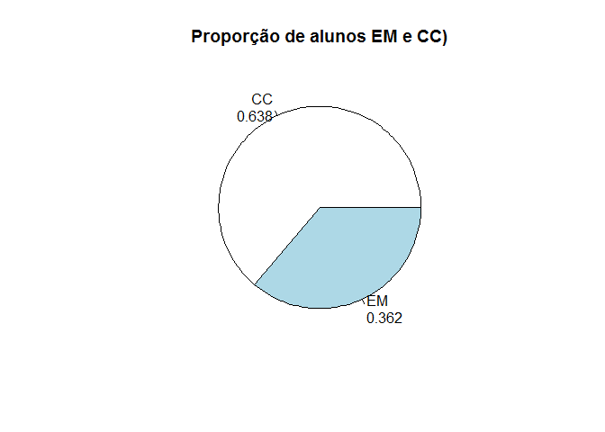

Proporção entre o numero de alunos quem evadiram de EM e CC e ambos

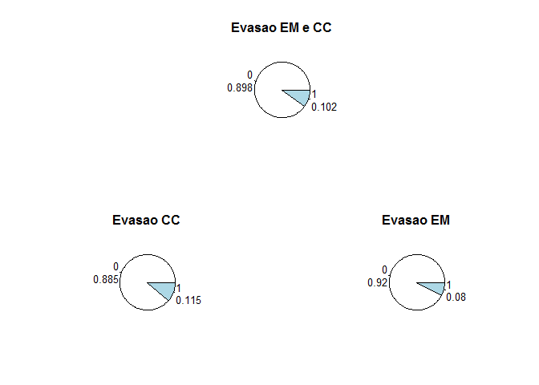

Procurar atributos que dividem os dados: Numero de cadeiras influencia na evasão?

```
##
##         0     1
##   1 0.750 0.250
##   2 0.846 0.154
##   3 0.786 0.214
##   4 0.844 0.156
##   5 0.837 0.163
##   6 0.924 0.076
##   7 0.931 0.069
##   8 1.000 0.000
```

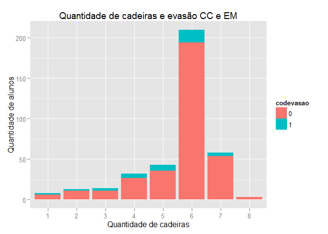

```
##
##         0     1
##   1 0.800 0.200
##   2 0.889 0.111
##   3 0.875 0.125
##   4 0.864 0.136
##   5 0.781 0.219
##   6 0.914 0.086
##   7 0.667 0.333
##   8 1.000 0.000
```

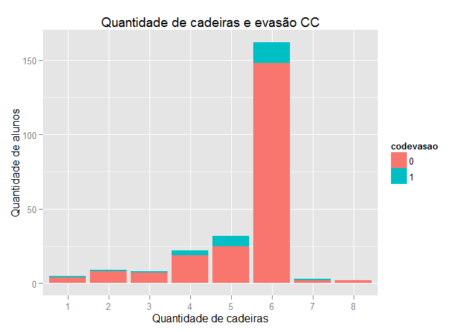

```
##
##         0     1
##   1 0.667 0.333
##   2 0.750 0.250
##   3 0.667 0.333
##   4 0.800 0.200
##   5 1.000 0.000
##   6 0.958 0.042
##   7 0.945 0.055
##   8 1.000 0.000
```

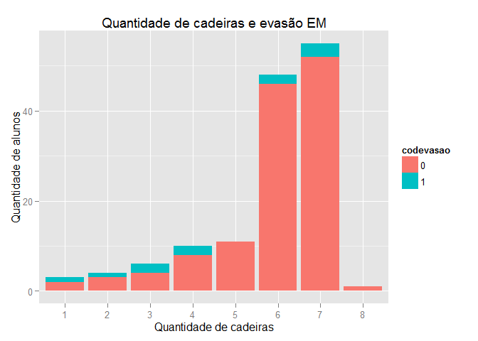

Media do aluno influencia na evasão? Para melhor visualizar melhor foi criado um novo campo ‘mediacat’ que separa as notas em:

- 0.0 - 2.5
- 2.5 - 5.0
- 5.0 - 7.5
- 7.5 - 10

```
##
##                 0     1
##   0.0 - 2.5 0.372 0.628
##   2.5 - 5.0 0.920 0.080
##   5.0 - 7.5 0.947 0.053
##   7.5 - 10. 1.000 0.000
```

[figure not shown]

```
##
##                 0     1
##   0.0 - 2.5 0.296 0.704
##   2.5 - 5.0 0.871 0.129
##   5.0 - 7.5 0.948 0.052
##   7.5 - 10. 1.000 0.000
```

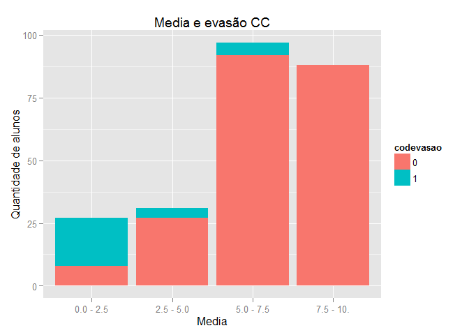

```
##
##                 0     1
##   0.0 - 2.5 0.500 0.500
##   2.5 - 5.0 1.000 0.000
##   5.0 - 7.5 0.944 0.056
##   7.5 - 10. 1.000 0.000
```

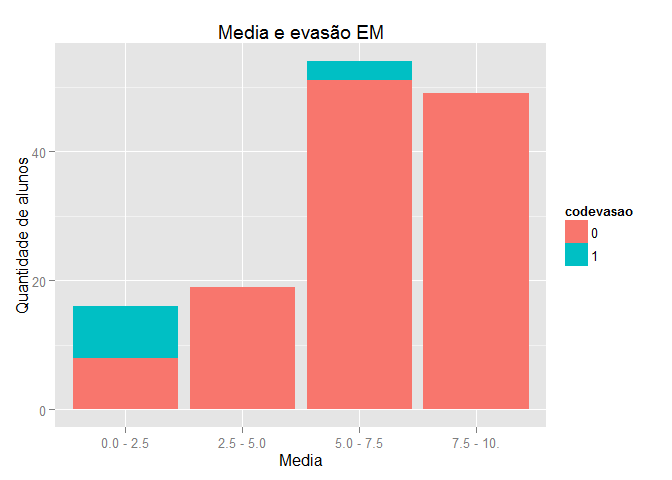

O número de reprovações influencia na evasão? Para melhor visualizar foi criado um novo atributo ‘reprovcat’ que separa os alunos entre:

- Reprovou nenhuma
- Reprovou até metade
- Reprovou mais da metade

```
##
##                      0     1
##   Ate metade     0.864 0.136
##   Mais da metade 0.800 0.200
##   Nenhuma        0.923 0.077
```

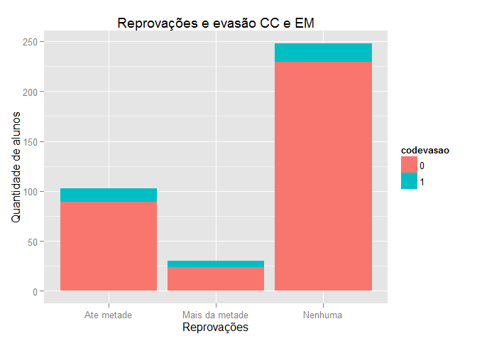

```
##
##                      0     1
##   Ate metade     0.815 0.185
##   Mais da metade 0.769 0.231
##   Nenhuma        0.934 0.066
```

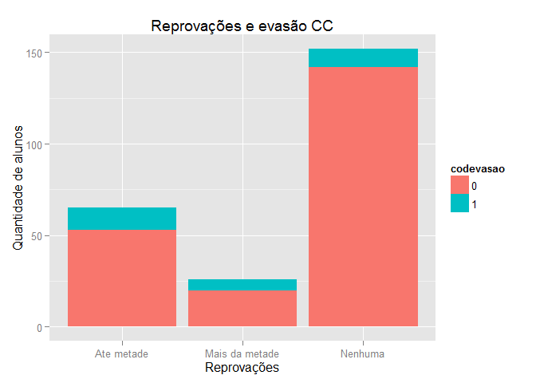

```
##
##                      0     1
##   Ate metade     0.947 0.053
##   Mais da metade 1.000 0.000
##   Nenhuma        0.906 0.094
```

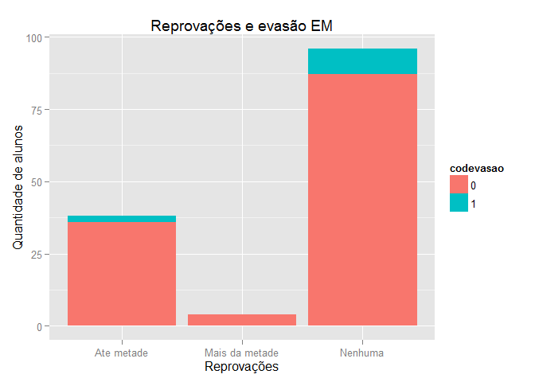

O número de reprovações por falta influencia na evasão? Para melhor visualizar foi criado um novo atributo ‘reprovcatf’ que separa os alunos entre:

- Reprovou nenhuma por falta
- Reprovou até metade por falta
- Reprovou mais da metade por falta

```
##
##                      0     1
##   Ate metade     0.853 0.147
##   Mais da metade 0.500 0.500
##   Nenhuma        0.946 0.054
```

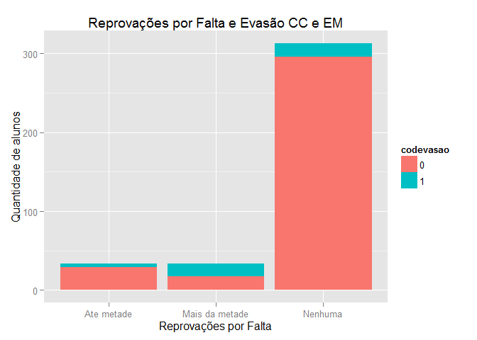

```
##
##                      0     1
##   Ate metade     0.706 0.294
##   Mais da metade 0.421 0.579
##   Nenhuma        0.942 0.058
```

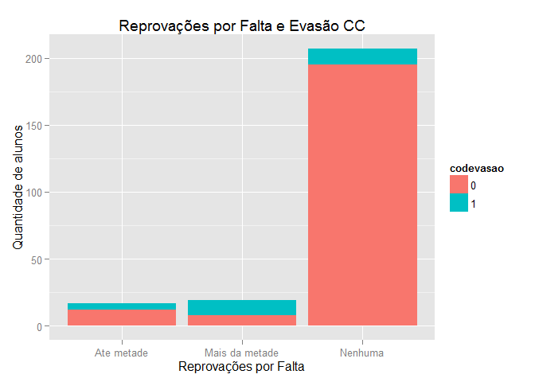

```
##
##                      0     1
##   Ate metade     1.000 0.000
##   Mais da metade 0.600 0.400
##   Nenhuma        0.953 0.047
```

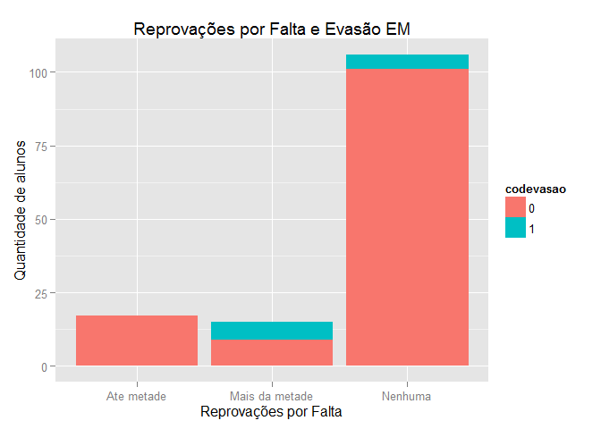